# R Programing For Biology Final Report

Chong Jia-Yun

2022/12/8

# Using R programming language to visualize the suspension rate of NTU students

## Background

When I was a freshman, I often heard a rumor from my seniors that the number of students in my department, Life Science, would be reduced by about 1/4 in second year, and then continue to decrease. However, it is difficult to judge the truth of this from the number of students in the classroom because of the differences in course selection. Is there a high percentage of suspensions in the department of Life Science? This project decided to use R programming language visualize the suspension rate of NTU students in the past ten years.

## Data and Library

The csv files and this script can be found in this [repository](https://github.com/nebula0/R_Programming_Final_Project). Import `ggplot2` for plotting, and `reshape2` to reshape the original dataframe to the format we want.

```r
# import library
library(ggplot2)
library(reshape2)
```

## Code

### Input data

Read in three dataframes. The original file doesn’t contain the column name, so we set `header` to `FALSE`. Use `str` to check the data type. The count of suspension numbers should be `int`, the department name should be `char`, and the semester should be `float`. I choose semester to be `float` because it is convenient to use when plotting. The hole number is the first semester and the hole number + 0.5 is the second semester. The three dataframes are:

- name_list: 科系代號.csv
- in_school: 在學人數表.csv
- quit_school: 休學統計表EXCEL.csv

```r
name_list <-  (read.csv("./csv_file/科系代號.csv", header = F, row.names = 1))
str(name_list)
```

```
## 'data.frame':    64 obs. of  1 variable:
##  $ V2: chr  "name" "中國文學系" "中國文學系國際學生學士班" "外國語文學系" ...
```

```r
in_school <- read.csv("./csv_file/在學人數表.csv", header = F, row.names = 1)
str(in_school)
```

```
## 'data.frame':    64 obs. of  20 variables:
##  $ V2 : int  101 16641 271 60 573 258 185 178 200 263 ...
##  $ V3 : num  102 16087 255 57 538 ...
##  $ V4 : int  102 21836 276 56 5647 250 196 178 203 259 ...
##  $ V5 : num  102 19030 267 57 543 ...
##  $ V6 : int  103 16843 262 60 559 244 189 183 208 244 ...
##  $ V7 : num  104 16178 251 58 543 ...
##  $ V8 : int  104 16641 271 60 573 258 185 178 200 263 ...
##  $ V9 : num  104 16087 255 57 538 ...
##  $ V10: int  105 21836 276 56 5647 250 196 178 203 259 ...
##  $ V11: num  106 19030 267 57 543 ...
##  $ V12: int  106 16843 262 60 559 244 189 183 208 244 ...
##  $ V13: num  106 16178 251 58 543 ...
##  $ V14: int  107 16843 262 60 559 244 189 183 208 244 ...
##  $ V15: num  108 16178 251 58 543 ...
##  $ V16: int  108 16641 271 60 573 258 185 178 200 263 ...
##  $ V17: num  108 16087 255 57 538 ...
##  $ V18: int  109 21836 276 56 5647 250 196 178 203 259 ...
##  $ V19: num  110 19030 267 57 543 ...
##  $ V20: int  110 16843 262 60 559 244 189 183 208 244 ...
##  $ V21: num  110 16178 251 58 543 ...
```

```r
head(in_school)
```

```
##         V2      V3    V4      V5    V6      V7    V8      V9   V10     V11
## year   101   101.5   102   102.5   103   103.5   104   104.5   105   105.5
## sum  16641 16087.0 21836 19030.0 16843 16178.0 16641 16087.0 21836 19030.0
## 1010   271   255.0   276   267.0   262   251.0   271   255.0   276   267.0
## 1011    60    57.0    56    57.0    60    58.0    60    57.0    56    57.0
## 1020   573   538.0  5647   543.0   559   543.0   573   538.0  5647   543.0
## 1030   258   250.0   250   238.0   244   230.0   258   250.0   250   238.0
##        V12     V13   V14     V15   V16     V17   V18     V19   V20     V21
## year   106   106.5   107   107.5   108   108.5   109   109.5   110   110.5
## sum  16843 16178.0 16843 16178.0 16641 16087.0 21836 19030.0 16843 16178.0
## 1010   262   251.0   262   251.0   271   255.0   276   267.0   262   251.0
## 1011    60    58.0    60    58.0    60    57.0    56    57.0    60    58.0
## 1020   559   543.0   559   543.0   573   538.0  5647   543.0   559   543.0
## 1030   244   230.0   244   230.0   258   250.0   250   238.0   244   230.0
```

```r
quit_school <- read.csv("csv_file/休學統計表EXCEL.csv", header = F, row.names = 1)
str(quit_school)
```

```
## 'data.frame':    64 obs. of  20 variables:
##  $ V2 : int  101 473 5 5 16 6 8 5 3 4 ...
##  $ V3 : num  102 546 8 6 19 ...
##  $ V4 : int  102 584 8 7 14 7 3 6 7 8 ...
##  $ V5 : num  102 634 10 6 13 ...
##  $ V6 : int  103 663 6 4 16 8 7 6 6 10 ...
##  $ V7 : num  104 677 7 5 19 ...
##  $ V8 : int  104 693 8 4 26 9 10 6 5 5 ...
##  $ V9 : num  104 670 6 4 27 ...
##  $ V10: int  105 704 12 4 27 6 9 4 4 11 ...
##  $ V11: num  106 731 14 4 23 ...
##  $ V12: int  106 789 16 6 22 15 8 6 3 6 ...
##  $ V13: num  106 802 12 6 20 ...
##  $ V14: int  107 807 15 7 25 12 11 5 6 8 ...
##  $ V15: num  108 873 11 6 26 ...
##  $ V16: int  108 890 14 12 20 8 10 8 5 10 ...
##  $ V17: num  108 902 12 10 23 ...
##  $ V18: int  109 879 9 10 19 5 8 8 5 5 ...
##  $ V19: num  110 890 8 9 21 ...
##  $ V20: int  110 712 7 8 18 6 9 12 10 6 ...
##  $ V21: num  110 743 8 7 16 ...
```

```r
head(quit_school)
```

```
##       V2    V3  V4    V5  V6    V7  V8    V9 V10   V11 V12   V13 V14   V15 V16
## year 101 101.5 102 102.5 103 103.5 104 104.5 105 105.5 106 106.5 107 107.5 108
## sum  473 546.0 584 634.0 663 677.0 693 670.0 704 731.0 789 802.0 807 873.0 890
## 1010   5   8.0   8  10.0   6   7.0   8   6.0  12  14.0  16  12.0  15  11.0  14
## 1011   5   6.0   7   6.0   4   5.0   4   4.0   4   4.0   6   6.0   7   6.0  12
## 1020  16  19.0  14  13.0  16  19.0  26  27.0  27  23.0  22  20.0  25  26.0  20
## 1030   6   5.0   7   6.0   8  12.0   9  15.0   6  10.0  15  13.0  12  11.0   8
##        V17 V18   V19 V20   V21
## year 108.5 109 109.5 110 110.5
## sum  902.0 879 890.0 712 743.0
## 1010  12.0   9   8.0   7   8.0
## 1011  10.0  10   9.0   8   7.0
## 1020  23.0  19  21.0  18  16.0
## 1030   6.0   5   6.0   6   9.0
```

### Preprocessing

```r
quit_ratio = quit_school

colnames(quit_school)
```

```
##  [1] "V2"  "V3"  "V4"  "V5"  "V6"  "V7"  "V8"  "V9"  "V10" "V11" "V12" "V13"
## [13] "V14" "V15" "V16" "V17" "V18" "V19" "V20" "V21"
```

```r
colnum <- dim(quit_school)[2] # 20
rownum <- dim(quit_school)[1] # 64

# calculate ratio
for (i in 1:colnum) {
    quit_ratio[2:rownum,i] <- (quit_school[2:rownum,i]/in_school[2:rownum,i]) * 100
}

# transpose the matrix, let departments and year be the column names.
t_quit_ratio <-  as.data.frame(t(quit_ratio))
```

### Plot single department

Define a function `get_line()`, the only input variable `query` is the department label. For example, Life Science is `B010`. This function will not return any value but plot the line plot of that department. `paste()` receive string and variables to form a new string allowing us to create unique title for each query.

```r
# define a function to plot corresponding plot.
get_line <- function(query){
y = t_quit_ratio[,query]
    title = paste("國立臺灣大學", name_list[query, 1],
                  "101 年至 111 年休學率", sep = "")

    ggplot(data = t_quit_ratio, aes(x = year, y = y)) +
        geom_line(aes(group=1)) +
        geom_point()  +
        theme(axis.text.x = element_text(angle = 60, vjust = 0.5, hjust=1)) +
        ylim(0, 20) +
        labs(
            x = "學年度",
            y = "百分比",
            title = title
        )
}
```

Now we can simply call the function to get the relative plot. Compare the total suspension rate and that in the department of Life Science, the later seems to be higher. Here we only use descriptive statistics rather than inferential statistics since I’m not confident in my statistics knowledge background.

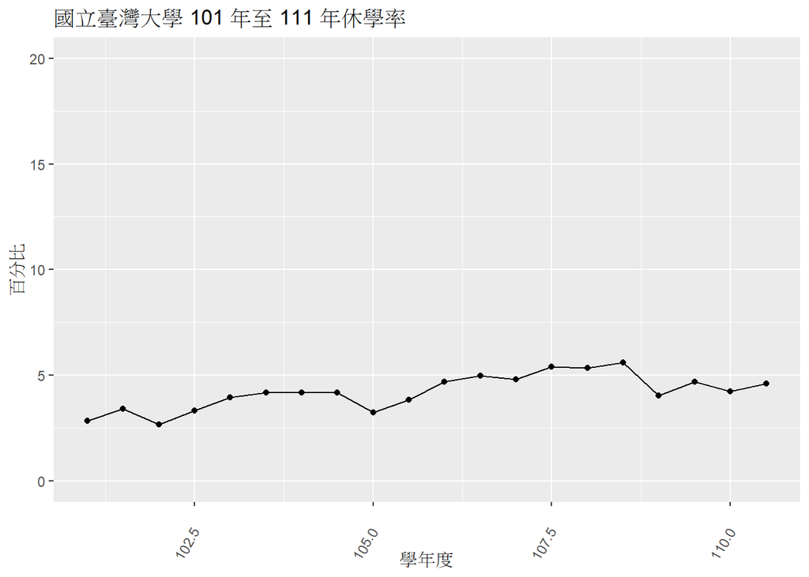

```r
# call the function
query <- "sum"
get_line(query)
```

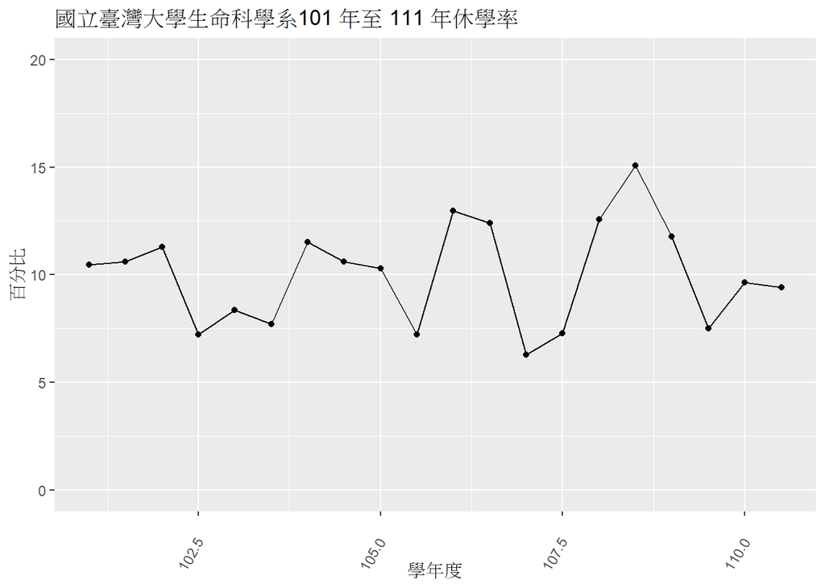

```r
query <- 'B010'
get_line(query)
```

### Plot multiple department

You may wander why can’t we plot all the line in the same plot, because there will be 64 lines which is very massy, like below:

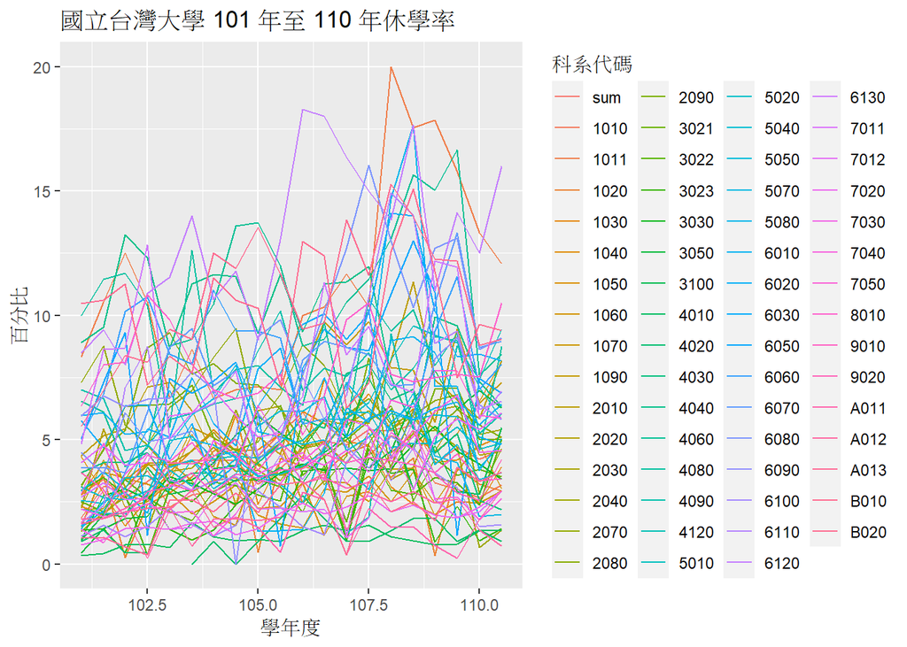

```r
t_quit_ratio_melt <- melt(t_quit_ratio, id.vars = 'year')
ggplot(data = t_quit_ratio_melt, aes(x = year, y = value, color = variable)) +
    ylim(0, 20) +
    geom_line() +
    labs(
        x = "學年度",
        y = "百分比",
        colour = "科系代碼",
        title = "國立台灣大學 101 年至 110 年休學率"
        )
```

So I’m going to make a function, when we call it, it can receive user input department code and get the plot. Only showing users interesting departments will be more useful compared to plotting them all at once. First create the `get_multiple_line` function that can make the plot, and call it in the `interactive_get_line` which can receive user input, and determine if the input is valid. In `interactive_get_line`, use a `while-loop` to get an input query until the user inserts `q`.

```r
# define a function to plot multiple line
get_multiple_line <- function(data){
    # t_quit_ratio_melt_select
    ggplot(data = data, aes(x = year, y = value, color = variable)) +
        ylim(0, 20) +
        geom_line() +
        labs(
            x = "學年度",
            y = "百分比",
            # title = title
            colour = "科系代碼",
            title = "國立台灣大學 101 年至 110 年休學率"
            )
}
```

```r
# define a function to plot multiple line according to user imput
interactive_get_line <- function(){
    temp <- ""
    count = 1;
    query_list <- c()
    while(temp != "q" & count < 64){
        temp = readline("輸入科系代碼，輸入 q 結束輸入:\n");
        if (temp != "q"){
            query_list[count] = temp
            count <- count +1
        }

    }
    valid = 1
    for (i in query_list) {
        if (!(i %in% rownames(name_list))){
            cat(i, "is not a valid query.\n")
            valid = 0
        }
    }

    if (valid){
        t_quit_ratio_melt_select <-
        t_quit_ratio_melt[as.character(t_quit_ratio_melt$variable) %in% query_list,]
        get_multiple_line(t_quit_ratio_melt_select)
    }
}
```

Pint the department code list first for user.

```r
print(name_list)
```

```
##                              V2
## number                     name
## 1010                 中國文學系
## 1011   中國文學系國際學生學士班
## 1020               外國語文學系
## 1030                   歷史學系
## 1040                     哲學系
## 1050                   人類學系
## 1060               圖書資訊學系
## 1070               日本語文學系
## 1090                   戲劇學系
## 2010                     數學系
## 2020                   物理學系
## 2030                     化學系
## 2040                 地質科學系
```

[output cut: 50 more lines]

Call the function. Because when saving Rmd to html, we cannot input query, so I command out this line.

```r
# interactive_get_line()
```

The output plot will look like this:

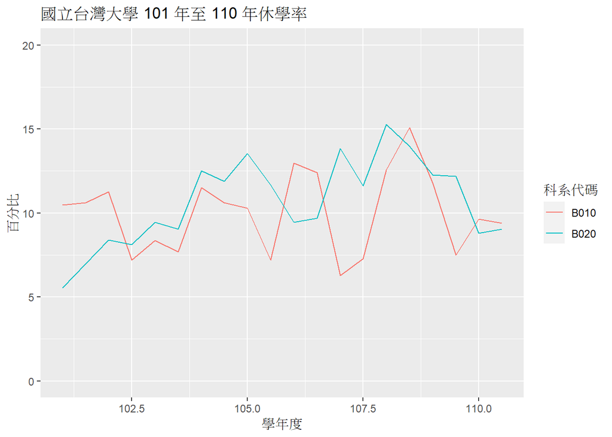

```r
query_list <- c("B010", "B020")
t_quit_ratio_melt_select <-
t_quit_ratio_melt[as.character(t_quit_ratio_melt$variable) %in% query_list,]
get_multiple_line(t_quit_ratio_melt_select)
```

### Original data source

- https://www.aca.ntu.edu.tw/w/aca/UAADStatistics_21071512245967154

### Reference

- https://stackoverflow.com/questions/41508459/reducing-number-of-decimal-places-in-x-axis-values-in-ggplot2-in-r
- https://stackoverflow.com/questions/40588050/plotting-a-line-for-each-row-in-a-dataframe-with-ggplot2-in-r